# Github Organization

23/09, 2021

## What is it

## What you can do

- Free
- Task Management
- Have roles (Owner, administrator, user)
- Generate teams
- Manage privacy of repositories
- Have a free webpage
- GitHub Actions (Check Packages automate running scripts)
- Mantain R packages

## Task management

## Task management

- Can be as manual or automated as wanted.
- Will always receive an email notification
- People form the organization can be tagged.
- On public projects it can be triggered by someone creating an issue

[figure not shown]

## Task management

- Personalized [tags](https://github.com/Sustainscapes/DataSciencePlanning/labels)

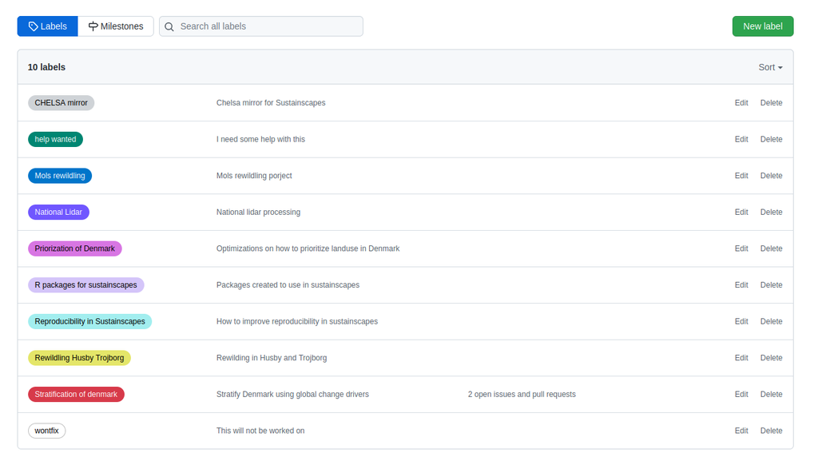

## Task management

- [Milestones](https://github.com/Sustainscapes/DataSciencePlanning/milestones) with due dates

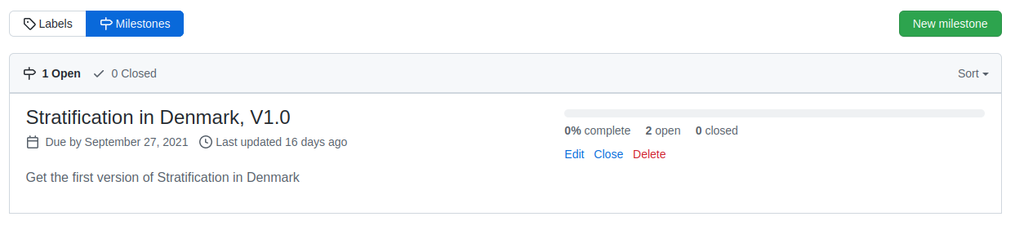

## Roles

## Roles

- Owner (Invite, generate teams, Generate templates, change privacy of repository, generate forums)
- Member (Create and work on Repos, Create projects, mention any visible team or member, Can be made a team maintainer)

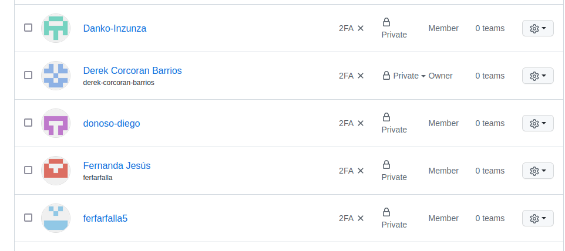

## Free website

## Free website

- Include schedulled programs
- Include interactive maps

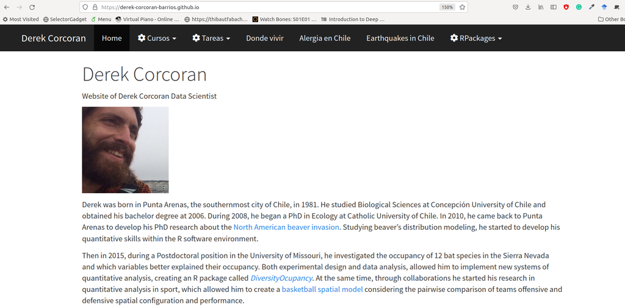

## Github Actions

## Github Actions

- Testing our scripts to make sure they work cross platform

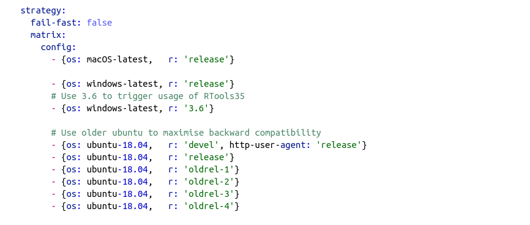

## Github Actions

- Schedulled actions
  - Update datasets
  - Update products (Maps, Latest publications etc)

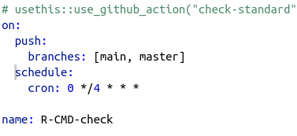

## Github Actions

- Small computers
- You can use 30 at the same time
- Up to 8 hours of free computing

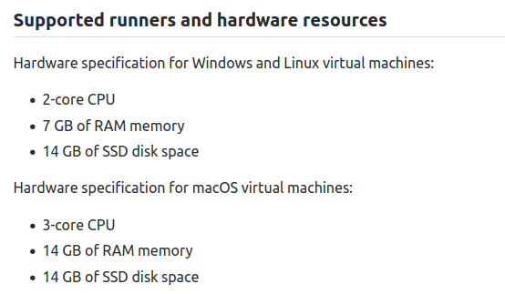

## Github Actions

- Linux (Ubuntu 16.04 to 20.04)
- MacOS (Catalina 10.15 and Big Sur 11)
- Windows (Windows Servers 2016, 2019, and 2022)